# Regression Models: Practice

Marcio Gualtieri

# Installing the Required Packages

You might need to install the following packages if you don’t already have them:

```r
install.packages("xtable")
install.packages("Amelia")
```

Just uncomment the packages you need and run this chunk before you run the remaining ones in this notebook.

# Importing the Required Packages

Once the libraries are installed, you need to load them as follows:

```r
suppressMessages(library(xtable))   # Pretty printing dataframes
suppressMessages(library(Amelia))   # Missing data
suppressMessages(library(graphics))
```

# Loading the Data-set

```r
company_data <- read.csv('_cf0fd3361e05f5be5304b07b771bad48_companydata.csv',
                         na.strings=c("NA", "NULL", ""), stringsAsFactors = F)
```

Let’s take a sample:

```r
render_table_in_viewer_pane <- function(data) {
  html <- print(xtable(data), type = "html", print.results=FALSE)
  temp <- tempfile(fileext = ".html")
  cat(html, file = temp)
  rstudioapi::viewer(temp)
}
render_table <- function(data) {
  render_table_in_viewer_pane(data)
  print(xtable(data), type = "html")
}
sample_data_frame <- function(data, size) {
  sample_index <- sample(1:nrow(data), size)
  return(data[sample_index, ])
}
render_table(sample_data_frame(company_data, 12))
```

|  | y | x1 | x2 | x3 |
| --- | --- | --- | --- | --- |
| 267 | 66.10 | 115.19 | 25.16 | -7.24 |
| 301 | 359.85 | 216.44 | 73.90 | -25.84 |
| 487 | 186.36 | 88.58 | 35.18 | -10.37 |
| 101 | 370.08 | 250.71 | 72.38 | 16.33 |
| 376 | 245.99 | 143.52 | 53.62 | 9.09 |
| 480 | 345.98 | 246.62 | 75.35 | -46.48 |
| 141 | 343.28 | 243.17 | 74.62 | 33.24 |
| 92 | 239.59 | 77.60 | 24.71 | 25.17 |
| 270 | 146.33 | 83.83 | 33.57 | -6.25 |
| 434 | 330.15 | 188.45 | 63.03 | 18.95 |
| 257 | 112.59 | 174.97 | 39.82 | 21.72 |
| 149 | 113.81 | 89.08 | 28.40 | 0.34 |

## Data Types

```r
str(company_data)
```

```
'data.frame':   500 obs. of  4 variables:
 $ y : num  162 186.3 339.3 388.4 90.2 ...
 $ x1: num  138 163 242 309 114 ...
 $ x2: num  41.2 49.8 65.8 92.7 36.1 ...
 $ x3: num  0.054 5.502 -53.189 4.377 7.278 ...
```

## Missing Data

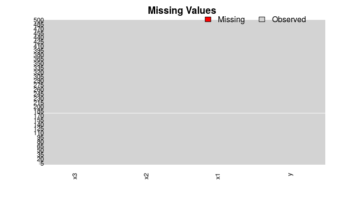

```r
missmap(company_data, main = "Missing Values", col = c("red", "lightgrey"))
```

The data-set seems complete (no `NA`s or `NULL`s).

# Relationship Between `y` and `x1`

1. [It has been widely noted that there is a relationship between x1 and y.] We are interested in studying the magnitude of this relationship and reporting results to the president of the company.

## Exploratory Data Analysis

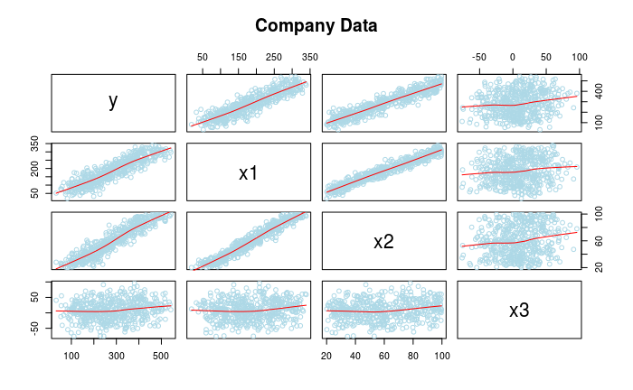

```r
pairs(company_data, panel = panel.smooth, main = "Company Data", col = "light blue")
```

## Fitting a Model for `y` and `x1`

Let’s fit a linear model first:

```r
fit <- lm(y ~ x1, data = company_data)
```

The plot for the fitted model is the following:

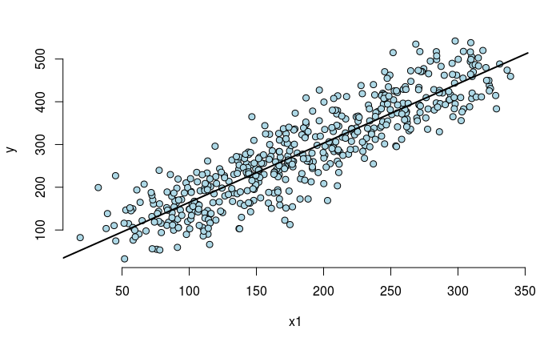

```r
plot(company_data$x1, company_data$y,
     xlab = "x1", ylab = "y",
     bg = "lightblue",
     col = "black", cex = 1.1, pch = 21, frame = FALSE)
abline(fit, lwd = 2)
```

It seems that there is a linear correlation between the variables `x1` and `y`, but also between the pairs (`x2`, `y`), (`x1`, `x2`) and (`x1`, `x2`). Given that (`x1`, `x2`) seem correlated, without any information about what these variables represent, there’s no way to tell if there is a meaningful relationship between (`y`, `x1`). Could actually be a meaninful relationship between (`x2`, `y`) or some other variable not included in the data-set paired with `y`.

# Coefficient for `x1`

2. Report the estimated coefficient for x1 from your model to 6 significant digits.

```r
summary(fit)
```

```
Call:
lm(formula = y ~ x1, data = company_data)

Residuals:
    Min      1Q  Median      3Q     Max
-156.06  -33.13   -1.23   36.09  139.83

Coefficients:
            Estimate Std. Error t value Pr(>|t|)
(Intercept) 25.94506    6.19828   4.186 3.36e-05 ***
x1           1.38705    0.03109  44.610  < 2e-16 ***
---
Signif. codes:  0 ‘***’ 0.001 ‘**’ 0.01 ‘*’ 0.05 ‘.’ 0.1 ‘ ’ 1

Residual standard error: 51.8 on 498 degrees of freedom
Multiple R-squared:  0.7998,    Adjusted R-squared:  0.7994
F-statistic:  1990 on 1 and 498 DF,  p-value: < 2.2e-16
```

Specifically, the coefficient of `x1` is:

```r
coefficients(fit)[2]
```

```
      x1
1.387047
```

# Confidence Interval

3. Report the 95% confidence interval for the coefficient for x1 from your model. Use 6 significant digits for both the lower and upper bounds. Report it in the format (Lower Bound, Upper Bound)

```r
coefs <- summary(fit)$coefficients
x1Coefs <- coefs[2, ]
x1Estimate <- x1Coefs[1]
x1StandardError <- x1Coefs[2]
x1Estimate + c(-1, 1) * qt(.975, df = fit$df) * x1StandardError
```

```
[1] 1.325958 1.448135
```

# P-Value for `X1`

4. Report the p-value associated with the coefficient for x1 from your model to 6 significant digits. Use scientific notation.

```r
x1Coefs[4]
```

```
     Pr(>|t|)
4.371503e-176
```